# Lab 6 - Regularized Regression

In this lab we'll explore regularized regression models to better understand how to handle the bias-variance trade off in parameterized machine learning models.

**Directions**: Please read through the contents of this lab with your partner and try the examples. After you're both confident that you understand a topic you should attempt the associated exercise and record your answer in your own Jupyter notebook that you will submit for credit. The notebook you submit should only contain answers to the lab's exercises (so you should remove any code you ran for the examples, or use a separate notebook to test out the examples).

To begin, you'll need the following libraries:

```python
import pandas as pd
import numpy as np
import matplotlib.pyplot as plt
import sklearn
import math
```

This lab's initial examples and questions will use the [superconductivity dataset](https://archive.ics.uci.edu/ml/datasets/Superconductivty+Data) from the UCI machine learning repository:

```python
### Read superconductivity data
sc = pd.read_csv("https://remiller1450.github.io/data/super.csv")

## Train-test split
from sklearn.model_selection import train_test_split
train_sc, test_sc = train_test_split(sc, test_size=0.2, random_state=5)

## Split predictors and outcome
train_y_sc = train_sc['critical_temp']
train_X_sc = train_sc.drop(['critical_temp'], axis=1)
train_X_sc.shape
```

```
(17010, 81)
```

The goal in this application was to predict the *critical temperature* of a material based upon its chemical properties. Critical temperature is the temperature at which the electrical resistivity of a material effectively vanishes. For most conductors, electrical resistivity gradually declines with temperature, but for superconductors it drops abruptly. The predictive features in this application were derived from the chemical formula of the material in question.

## Part 1 - Lasso and Ridge Regression in `sklearn`

Ridge and Lasso regression each have their own functions in `sklearn`, both of which are similar to `LinearRegression()` with an additional argument, `alpha`, that controls the amount of regularization.

However, it is unwise to simply throw these models into `GridSearchCV()` to tune `alpha` like we've done for other tuning parameters. To understand why, let's first create a regularization path plot:

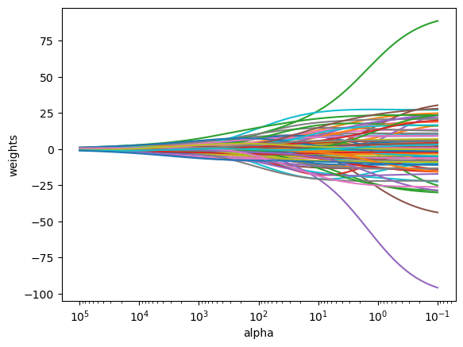

```python
from sklearn.linear_model import Ridge
from sklearn.preprocessing import StandardScaler

## Standardize
train_Xs_sc = StandardScaler().fit_transform(train_X_sc)

## Set up sequence of alphas
n_alphas = 200
alphas = np.logspace(-1, 5, n_alphas)

## Find coefficients at each alpha (Ridge regression)
coefs = []
for a in alphas:
    ridge = Ridge(alpha=a)
    ridge.fit(train_Xs_sc, train_y_sc)
    coefs.append(ridge.coef_)

## Create Plot
ax = plt.gca()
ax.plot(alphas, coefs)
ax.set_xscale("log")
ax.set_xlim(ax.get_xlim()[::-1])  # reverse axis
plt.xlabel("alpha")
plt.ylabel("weights")
plt.axis("tight")
plt.show()
```

Notice that the regularization plot is smooth, meaning the estimated weights at nearby values of `alpha` are similar.

Lasso and Elastic Net regression do not have closed form solutions and instead the optimal weights are found using iterative algorithms. We want to avoid "starting from scratch" when we estimate the optimal weights at each value of `alpha`, so we should use specialized functions (`RidgeCV()` and `LassoCV()`) that employ a warm start strategy (initializing using results from an adjacent value of `alpha`):

```python
from sklearn.linear_model import RidgeCV

## Set up sequence of alphas
n_alphas = 200
alphas = np.logspace(-1, 5, n_alphas)

## Evaluate using 5-fold CV and print the best alpha
ridge_cv_res = RidgeCV(cv=5, alphas = alphas, scoring='neg_mean_squared_error').fit(train_Xs_sc, train_y_sc)
best_alpha = ridge_cv_res.alpha_
print(best_alpha)
```

```
0.11489510001873092
```

```python
## Compare w/ what we'd get from LinearRegression() using 5-fold CV
from sklearn.linear_model import LinearRegression
from sklearn.model_selection import cross_val_score
lm_score = cross_val_score(LinearRegression(), train_Xs_sc, train_y_sc, scoring='neg_mean_squared_error', cv = 5)
ridge_score = cross_val_score(Ridge(alpha=best_alpha), train_Xs_sc, train_y_sc, scoring='neg_mean_squared_error', cv = 5)
print("OLS:", np.average(lm_score), "Ridge:", np.average(ridge_score))
```

```
OLS: -309.5888872062948 Ridge: -309.5656322375192
```

**Question #1**: The `Lasso()` function in `sklearn` is directly comparable to `Ridge()`.

- **Part A**: Create a sequence of 50 values of `alpha` using `np.logspace()` going from 0.1 to 100. Then, using the example in this section as a template, create the regularization path plot for a Lasso model applied to the superconductivity data.
- **Part B**: Inspect the regularization path plot you created in Part A and estimate how many features have non-zero weights when the penalty parameter is `alpha = 10`.
- **Part C**: Use `LassoCV()` to perform 5-fold cross-validation in order to find the optimal value of `alpha` from the sequence you created in Part A. Because the function does not have a `scoring` argument, you may rely upon the default scoring metric ($R^2$) to select the best `alpha`.
- **Part D**: Use `GridSearchCV()` to compare the best performing Lasso model from Part C with the best Ridge model (found in the example) and an ordinary linear regression model using mean squared error as the scoring metric. The purpose of this comparison is to ensure the exact same CV folds are used for each model. Report the cross-validated RMSE of each model.
- **Part E**: Compare the Ridge regression and Lasso regression regularization plots at each model's respective best `alpha` and briefly comment upon why you believe the Lasso model at the value of `alpha` identified in Part C performed better/worse than the Ridge model at its best value of `alpha`.

## Part 2 - Regularized Logistic Regression

In a previous lab, we noted that `sklearn`'s implementation of logistic regression applies regularization by default, which is why we provided the argument `penalty='none'`.

To further understand how regularization is implemented in this model, as well as why it is useful, we'll use the MNIST handwritten digit data set. Specifically, we'll see if we can use pixel intensities as features in logistic regression to predict whether or not a digit is a four.

```python
### Read flattened MNIST data
mnist = pd.read_csv("https://remiller1450.github.io/data/mnist_small.csv")

## Train-test split
from sklearn.model_selection import train_test_split
train_mnist, test_mnist = train_test_split(mnist, test_size=0.2, random_state=5)

### Separate the label column (outcome)
train_mnist_y = train_mnist['label']
train_mnist_X = train_mnist.drop(['label'], axis="columns")

### Create a binary label for 4's
train_mnist_y_binary = (train_mnist_y == 4).astype(int)
```

To begin, let's consider a simple pipeline that fits a logistic regression model without any regularization:

```python
from sklearn.linear_model import LogisticRegression
from sklearn.pipeline import Pipeline

pipe = Pipeline([
('model', LogisticRegression(penalty=None, solver='saga'))
])

log_mod = pipe.fit(train_mnist_X, train_mnist_y_binary)
```

This model fails to converge, meaning an optimal set of weight parameters, $\{w_0, w_1, \ldots, w_p\}$, could not be determined. There are a few reasons why this can happen that you should be aware of:

1. *Numerical instability* - the numbers involved in the optimization are so big (or so small) that it becomes difficult for Python to keep track of the required number of digits.
2. *Perfect separation* - the positive class can be perfectly separated from the negative class, leading to there being infinitely many sigmoid curves that could produce similarly accurate predictions

As you might expect, both of these issues can be addressed via regularization, but your first strategy should be to rescale the input features and modify the optimization algorithm and parameters (the type of solver, number of iterations, and tolerance).

```python
## Modify and re-fit the logistic regression pipeline
from sklearn.preprocessing import MinMaxScaler
new_pipe = Pipeline([
('scaler', MinMaxScaler()),
('model', LogisticRegression(penalty=None, solver='lbfgs', max_iter=150))
])

new_log_mod = new_pipe.fit(train_mnist_X, train_mnist_y_binary)
```

These changes were enough to allow convergence, meaning the optimization algorithm got close enough to an optimal set of weights that the weight estimates were no longer changing by more than a certain level of tolerance.

To further understand what is happening here it can be helpful to plot a logistic regression model's linear predictors vs. its predicted probabilities:

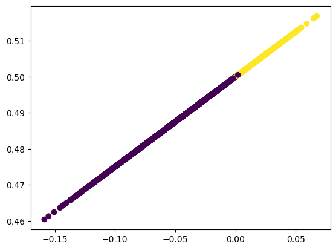

```python
## Extract the weights and bias from the fitted model
w = log_mod.named_steps['model'].coef_
b = log_mod.named_steps['model'].intercept_

## Calculate the linear predictor using the dot product of X and w + the bias term
lin_predictor = np.dot(MinMaxScaler().fit_transform(train_mnist_X), np.transpose(w)) + b

## Apply the sigmoid transformation
pi = 1/(1 + np.exp(-lin_predictor))

## Plot the original model (which failed to converge)
plt.scatter(lin_predictor, pi, c=train_mnist_y_binary.astype('category'))
plt.show()
```

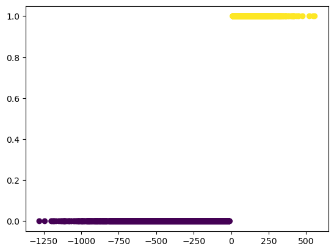

```python
## Plot the new model (which converged)
w = new_log_mod.named_steps['model'].coef_
b = new_log_mod.named_steps['model'].intercept_
lin_predictor = np.dot(MinMaxScaler().fit_transform(train_mnist_X), np.transpose(w)) + b
pi = 1/(1 + np.exp(-lin_predictor))
plt.scatter(lin_predictor, pi, c=train_mnist_y_binary.astype('category'))
plt.show()
```

**Question #2**:

- **Part A**: Calculate the classification accuracy of the converged logistic regression model from this section's examples using the training data. Briefly explain how this model's perfect accuracy score relates to the plot that appears just prior to this question.
- **Part B**: Now do the same for the model that failed to converge, noting its accuracy score is slightly less than perfect. How does this accuracy score relate to what you see in the plot of this model's linear predictors vs. its predicted probabilities?
- **Part C**: Now use `cross_val_predict()` to obtain cross-validated predictions using 3-fold cross-validation for each training sample using the pipeline that had converged with the full training set. What is the cross-validated accuracy score of this model? Why might it not be as high as the accuracy score you found in Parts A and B?

$~$

Now let's consider regularization as a way to handle the issues we encountered in this section. The `LogisticRegression()` function uses the argument `C` to control the *inverse* of the regularization strength. Thus, unlike how `alpha` works in Lasso and Ridge regression, smaller values of `C` impose a greater penalty upon the weight vector.

The code below demonstrates how we can use this argument to add a Ridge penalty to logistic regression and show the regularization path plot:

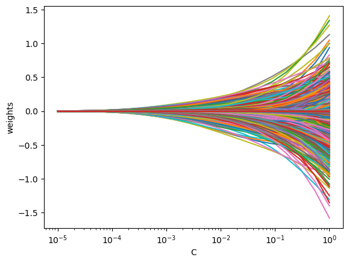

```python
## Set up sequence of "C" values
n_c = 20
c_vals = np.logspace(-5, 0, n_c)

ridge_pipe = Pipeline([
('scaler', MinMaxScaler()),
('model', LogisticRegression(penalty="l2", solver='lbfgs', warm_start=True, max_iter=150))
])

## Fit the pipeline to each value of C
coefs = []
for c in c_vals:
    ridge_pipe.set_params(model__C=c)
    ridge_pipe.fit(train_mnist_X, train_mnist_y_binary)
    coefs.append(ridge_pipe.named_steps['model'].coef_.ravel())

## Create Plot
ax = plt.gca()
ax.plot(c_vals, coefs)
ax.set_xscale("log")
plt.xlabel("C")
plt.ylabel("weights")
plt.axis("tight")
plt.show()
```

Similar to Part 1 of the lab, `sklearn` has a specialized function `LogisticRegressionCV()` that uses the "warm start" strategy for more effective turning of `C`. This function is demonstrated below:

```python
## Perform cross-validated search for C
c_vals = np.logspace(-4, -1, 6)
from sklearn.linear_model import LogisticRegressionCV
cv_lr_mod = LogisticRegressionCV(cv=3, Cs = c_vals, penalty="l2", solver="lbfgs", max_iter=150).fit(train_mnist_X, train_mnist_y_binary)

## Print the best value of C
print(cv_lr_mod.C_)

## Print the cross-validated score
print(cv_lr_mod.score(train_mnist_X, train_mnist_y_binary))
```

```
[0.0001]
0.9991666666666666
```

**Question #3**:

- **Part A**: Following the examples in this section, display the regularization path plot of a logistic regression model that uses L1 regularization. Your model should use the "liblinear" `solver`. Consider 25 different logarithmically spaced values of `C` ranging from $10^-4$ to 1 when creating your plot.
- **Part B**: Comparing the regularization path plots for L1 and L2 regularization, how many variables appear to have non-zero weights in the model using L1 regularization when `C=10^-3`? How many variables have non-zero weights in the model using L2 regularization when `C=10^-3`?
- **Part C**: Use `LogisticRegressionCV()` to select an optimal value of `C` for the model you considered in Part A using 3-fold cross-validation. Report the optimal value and the corresponding cross-validated accuracy score.
- **Part D**: `LogisticRegressionCV()` stores the estimated weights of the model with the best performing value of `C`. Use these estimated weights to report the *sparsity* of the best model. That is, what proportion of input features had weight estimates that were exactly zero?

## Part 3 - Application

This application will use many of the core machine learning steps we've engaged with throughout the entire semester up until this point.

You will work with the [Ames Housing data set](https://jse.amstat.org/v19n3/decock/DataDocumentation.txt), which is slightly dated (it contains homes sold between 2006 and 2010) but remains one of the most comprehensive publicly available housing data sets.

The goal of the application is to accurately predict sale prices based upon features that would be available before a home is sold. The steps involved in Question #4 will also introduce a few new functions that are minor extensions of what we've seen in this lab and previous ones.

```python
## Read the data
ames = pd.read_csv("https://remiller1450.github.io/data/AmesHousing.csv")

## Train-test split
from sklearn.model_selection import train_test_split
train_ames, test_ames = train_test_split(ames, test_size=0.2, random_state=9)

## Separate y and X
train_ames_y = train_ames['SalePrice']
train_ames_X = train_ames.drop('SalePrice', axis=1)

## Note the presence of missing data
print(train_ames_X.isna().sum().sort_values(ascending=False))

## We'll also remove any variables with more than 1000 missing values
## they have too much missing data to reliably impute.
train_ames_X = train_ames_X[train_ames_X.columns[train_ames_X.isna().sum() < 1000]]
```

```
Pool.QC           2333
Misc.Feature      2263
Alley             2193
Fence             1903
Fireplace.Qu      1136
                  ...
Heating.QC           0
Central.Air          0
X1st.Flr.SF          0
X2nd.Flr.SF          0
Sale.Condition       0
Length: 81, dtype: int64
```

**Question #4**:

- **Part A**: Consider variables contained in `train_ames_X` and drop anything that should be used as a predictor. For example, you may assume that the property identification number has no predictive value since it arbitrarily assigned by the county. Relatedly, variables like `Yr.Sold` would not be available for a home that has just gone on the market, so it isn't relevant for prediction in our context. Finally, you may remove the variable `MS.SubClass` for simplicity.
- **Part B**: Create a histogram of each numeric predictor and determine whether there are any features that are candidates for normalization in a preprocessing pipeline. For this part you merely need to create the histograms and identify the features, you do not need to set up a pipeline or perform any transformations yet.
- **Part C**: Create separate lists of all categorical and all numerical predictors you plan to use in your model. You might consider using the `select_dtypes()` method to facilitate this.
- **Part D**: Create a pipeline involving two steps, preprocessing and modeling. The preprocessing step should apply different functions to categorical and numerical predictors using the lists you created in Part C. For numeric predictors, you should apply standardization/scaling, normalization or passthrough, and KNN imputation of missing data using [KNNImputer()](https://scikit-learn.org/stable/modules/generated/sklearn.impute.KNNImputer.html) with the default arguments. For categorical predictors, you should apply one-hot encoding. The modeling step should use `ElasticNetCV()` with 5-fold cross-validation and sequences of reasonably chosen `alpha` values and `l1_ratio` values (aim to use approximately 30 different alpha values and 3-5 different `l1_ratio` values)
- **Part E**: Fit the pipeline you created in Part D and report the optimal values of `alpha` and `l1_ratio`.
- **Part F**: Use a similar pipeline to one you created in Part D to determine a well-fitting KNN model. You should use this pipeline and `GridSearchCV()` to find appropriate values of the `n_neighbors` and `weights` hyperparameters.
- **Part G**: Compare the performance of the best fitting KNN and elastic net models *on the test set*.